# makin_hw1 slides

**Общая информация**

**Срок сдачи:** 18 октября 2018, 06:00 <br> **Штраф за опоздание:** -2 балла после 06:00 18 октября, -4 балла после 06:00 25 октября, -6 баллов после 06:00 1 ноября

При отправлении ДЗ указывайте фамилию в названии файла Присылать ДЗ необходимо в виде ссылки на свой github репозиторий в slack @alkhamush

Необходимо в slack создать таск в приватный чат: /todo Фамилия Имя ссылка на гитхаб @alkhamush Пример: /todo Ксения Стройкова https://github.com/stroykova/spheremailru/stroykova_hw1.ipynb @alkhamush Дополнительно нужно просто скинуть ссылку в slack в личный чат

Используйте данный Ipython Notebook при оформлении домашнего задания.

###### Задание 1 (2 баллов)

Реализовать KNN в классе MyKNeighborsClassifier (обязательное условие: точность не ниже sklearn реализации) Разберитесь самостоятельно, какая мера расстояния используется в KNeighborsClassifier дефолтно и реализуйте свой алгоритм именно с этой мерой. Самостоятельно разберитесь, как считается score из KNeighborsClassifier и реализуйте аналог в своём классе. Score не должен уступать значению KNN из sklearn

###### Задание 2 (2 балла)

Добиться скорости работы на fit, predict и predict_proba сравнимой со sklearn для iris и mnist Для этого используем numpy

###### Задание 3 (2 балла)

Для iris найдите такой параметр n_neighbors, при котором выдаётся наилучший score. Нарисуйте график зависимости score от n_neighbors

###### Задание 4 (3 балла)

Добавить algorithm='kd_tree' в реализацию KNN (использовать KDTree из sklearn.neighbors). Значение n_neighbors нужно взять из задания 3. Добиться скорости работы на fit, predict и predict_proba сравнимой со sklearn для iris и mnist Для этого используем numpy. Score не должен уступать значению KNN из sklearn

###### Задание 5 (1 балла)

Описать для чего нужны следующие библиотеки/классы/функции (список будет ниже)

**Штрафные баллы:**

1. Невыполнение PEP8 -1 балл
2. Отсутствие фамилии в имени скрипта (скрипт должен называться по аналогии со stroykova_hw1.ipynb) -1 балл
3. Все строчки должны быть выполнены. Нужно, чтобы output команды можно было увидеть уже в git'е. В противном случае -1 балл
4. При оформлении ДЗ нужно пользоваться данным файлом в качестве шаблона. Не нужно удалять и видоизменять структуру кода и текст. В противном случае -1 балл

Задание 1, 2

```python
import numpy as np
import matplotlib.pyplot as plt
import seaborn as sns

from sklearn.neighbors import KDTree
from sklearn import datasets
from sklearn.base import ClassifierMixin
from sklearn.datasets import fetch_mldata
from sklearn.neighbors.base import NeighborsBase, KNeighborsMixin, SupervisedIntegerMixin
from sklearn.model_selection import train_test_split
from sklearn.neighbors import KNeighborsClassifier
%load_ext pycodestyle_magic
```

```
The pycodestyle_magic extension is already loaded. To reload it, use:
  %reload_ext pycodestyle_magic
```

```python
%%pycodestyle


class MyKNeighborsClassifier(
    NeighborsBase, KNeighborsMixin,
    SupervisedIntegerMixin, ClassifierMixin
):
    """Classifier implementing the k-nearest neighbors vote"""

    def __init__(self, n_neighbors, algorithm='brute'):
        self.n_neighbors = n_neighbors
        self.algorithm = algorithm

    def fit(self, X, y):

        self._X = np.array(X, dtype=np.float32)
        self._y = np.array(y, dtype=np.int)
        self._classes = np.unique(self._y)

    def pre_predict(self, X):

        if self.algorithm == 'brute':
            dist_train_X = ((self._X) ** 2).sum(axis=1).reshape(1, -1)
            dist_test_X = ((X) ** 2).sum(axis=1).reshape(-1, 1)
            distance = dist_train_X + dist_test_X - 2*np.matmul(X, self._X.T)
            indices_neighbors = np.argsort(distance)[:, :self.n_neighbors]
            class_of_test = self._y[indices_neighbors]

        if self.algorithm == 'kd_tree':
            tree = KDTree(self._X)
            _, ind = tree.query(X, k=self.n_neighbors)
            class_of_test = self._y[ind]
        return class_of_test

    def predict(self, X):

        forecast = np.zeros((X.shape[0]))

        class_of_test = self.pre_predict(X)
        for i, elem in enumerate(class_of_test):
            unique, pos = np.unique(elem, return_inverse=True)
            maxpos = np.bincount(pos).argmax()
            forecast[i] = unique[maxpos]
        return forecast

    def predict_proba(self, X):

        forecast = np.zeros(((X.shape[0]), int(self._y.max())+1))

        class_of_test = self.pre_predict(X)
        for i, elem in enumerate(class_of_test):
            result_of_freq = np.zeros(int(self._y.max())+1)
            for j in self._classes:
                result_of_freq[j] = sum(elem == j)
            forecast[i] = result_of_freq / self.n_neighbors
        return forecast

    def score(self, X, y):
        return sum(self.predict(X) == y) / X.shape[0]
```

**IRIS**

```python
iris = datasets.load_iris()
```

```python
X_train, X_test, y_train, y_test = train_test_split(
    iris.data, iris.target,
    test_size=0.1, stratify=iris.target
)
```

```python
clf = KNeighborsClassifier(n_neighbors=2)
my_clf = MyKNeighborsClassifier(n_neighbors=2)
```

```python
%time clf.fit(X_train, y_train)
```

```
CPU times: user 746 µs, sys: 0 ns, total: 746 µs
Wall time: 509 µs
```

```
KNeighborsClassifier(algorithm='auto', leaf_size=30, metric='minkowski',
           metric_params=None, n_jobs=None, n_neighbors=2, p=2,
           weights='uniform')
```

```python
%time my_clf.fit(X_train, y_train)
```

```
CPU times: user 730 µs, sys: 0 ns, total: 730 µs
Wall time: 544 µs
```

```python
%time clf.predict(X_test)
```

```
CPU times: user 2.9 ms, sys: 361 µs, total: 3.26 ms
Wall time: 2.7 ms
```

```
array([2, 1, 0, 2, 1, 1, 0, 1, 2, 0, 1, 2, 2, 0, 0])
```

```python
%time my_clf.predict(X_test)
```

```
CPU times: user 7.39 ms, sys: 423 µs, total: 7.82 ms
Wall time: 4.65 ms
```

```
array([2., 1., 0., 2., 1., 1., 0., 1., 2., 0., 1., 2., 2., 0., 0.])
```

```python
%time clf.predict_proba(X_test)
```

```
CPU times: user 5.58 ms, sys: 0 ns, total: 5.58 ms
Wall time: 3.61 ms
```

```
array([[0., 0., 1.],
       [0., 1., 0.],
       [1., 0., 0.],
       [0., 0., 1.],
       [0., 1., 0.],
       [0., 1., 0.],
       [1., 0., 0.],
       [0., 1., 0.],
       [0., 0., 1.],
       [1., 0., 0.],
       [0., 1., 0.],
       [0., 0., 1.],
       [0., 0., 1.],
       [1., 0., 0.],
       [1., 0., 0.]])
```

```python
%time my_clf.predict_proba(X_test)
```

```
CPU times: user 750 µs, sys: 7.6 ms, total: 8.35 ms
Wall time: 4.99 ms
```

```
array([[0., 0., 1.],
       [0., 1., 0.],
       [1., 0., 0.],
       [0., 0., 1.],
       [0., 1., 0.],
       [0., 1., 0.],
       [1., 0., 0.],
       [0., 1., 0.],
       [0., 0., 1.],
       [1., 0., 0.],
       [0., 1., 0.],
       [0., 0., 1.],
       [0., 0., 1.],
       [1., 0., 0.],
       [1., 0., 0.]])
```

```python
clf.score(X_test, y_test)
```

```
1.0
```

```python
my_clf.score(X_test, y_test)
```

```
1.0
```

Задание 3

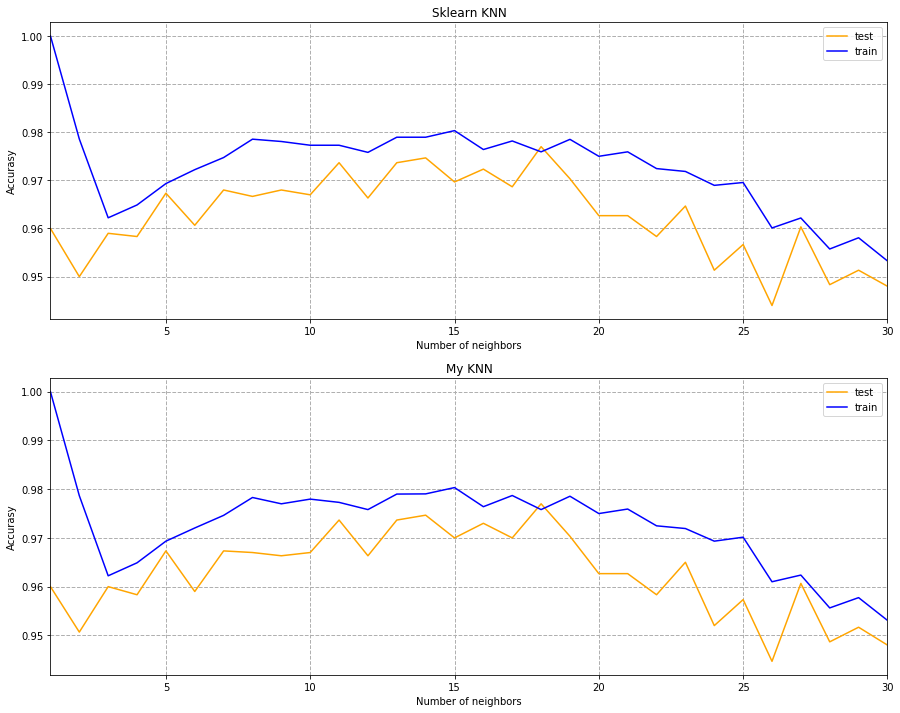

```python
Max_N = 31
Number_of_test = 200
MyKNN_train_score = np.zeros(Max_N-1)
MyKNN_test_score = np.zeros(Max_N-1)
KNN_train_score = np.zeros(Max_N-1)
KNN_test_score = np.zeros(Max_N-1)
x_ax = np.arange(1, Max_N)
for i in range(1, Max_N):
    MyKNN_test = []
    MyKNN_train = []
    KNN_test = []
    KNN_train = []
    for j in range(Number_of_test):
        iris = datasets.load_iris()
        X_train, X_test, y_train, y_test = train_test_split(
            iris.data, iris.target,
            test_size=0.1, stratify=iris.target
        )
        my_clf = MyKNeighborsClassifier(n_neighbors=i)
        my_clf.fit(X_train, y_train)
        MyKNN_test.append(my_clf.score(X_test, y_test))
        MyKNN_train.append(my_clf.score(X_train, y_train))

        clf = KNeighborsClassifier(n_neighbors=i)
        clf.fit(X_train, y_train)
        KNN_test.append(clf.score(X_test, y_test))
        KNN_train.append(clf.score(X_train, y_train))

    MyKNN_train_score[i-1] = np.mean(MyKNN_train)
    MyKNN_test_score[i-1] = np.mean(MyKNN_test)
    KNN_train_score[i-1] = np.mean(KNN_train)
    KNN_test_score[i-1] = np.mean(KNN_test)

# plots
plt.figure(figsize=(15, 12))

plt.subplot(2, 1, 1)
plt.xlim(1, Max_N-1)
plt.title("Sklearn KNN")
plt.plot(np.arange(1, Max_N), KNN_test_score, label="test", color="orange")
plt.plot(np.arange(1, Max_N), KNN_train_score, label="train", color="blue")
plt.xlabel('Number of neighbors')
plt.ylabel('Accurasy')
plt.legend()
plt.grid(linestyle='--', linewidth=1)

plt.subplot(2, 1, 2)
plt.xlim(1, Max_N-1)
plt.title("My KNN")
plt.plot(np.arange(1, Max_N), MyKNN_test_score, label="test", color="orange")
plt.plot(np.arange(1, Max_N), MyKNN_train_score, label="train", color="blue")
plt.xlabel('Number of neighbors')
plt.ylabel('Accurasy')
plt.legend()
plt.grid(linestyle='--', linewidth=1)
plt.show()
```

```python
k_of_n = [i+1 for i in reversed(np.argsort(MyKNN_test_score))]
N = 10
print("-"*16, "Топ", N, "-"*16)
for i in range(N):
    print("Количество соседей = ", k_of_n[i],
          " -> Score = ", round(MyKNN_test_score[k_of_n[i]-1], 3))
print("-"*40)
print("Лучший результат получается если количество соседей = ", k_of_n[0])
```

```
---------------- Топ 10 ----------------
Количество соседей =  18  -> Score =  0.977
Количество соседей =  14  -> Score =  0.975
Количество соседей =  13  -> Score =  0.974
Количество соседей =  11  -> Score =  0.974
Количество соседей =  16  -> Score =  0.973
Количество соседей =  19  -> Score =  0.97
Количество соседей =  15  -> Score =  0.97
Количество соседей =  17  -> Score =  0.97
Количество соседей =  5  -> Score =  0.967
Количество соседей =  7  -> Score =  0.967
----------------------------------------
Лучший результат получается если количество соседей =  18
```

**MNIST**

```python
#does't work
#mnist = fetch_mldata('MNIST original')
```

```python
from six.moves import urllib
from sklearn.datasets import fetch_mldata
try:
    mnist = fetch_mldata('MNIST original')
except:
    print("Could not download MNIST data from mldata.org",
          "trying alternative...")

    # Alternative method to load MNIST, if mldata.org is down
    from scipy.io import loadmat
    mnist_alternative_url = "https://github.com/amplab/datascience-sp14/raw/master/lab7/mldata/mnist-original.mat"
    mnist_path = "./mnist-original.mat"
    response = urllib.request.urlopen(mnist_alternative_url)
    with open(mnist_path, "wb") as f:
        content = response.read()
        f.write(content)
    mnist_raw = loadmat(mnist_path)
    mnist = {
        'data': mnist_raw["data"].T,
        'target': mnist_raw["label"][0],
        "COL_NAMES": ["label", "data"],
        "DESCR": "mldata.org dataset: mnist-original",
    }
    print("Success!")
```

```
Could not download MNIST data from mldata.org trying alternative...
Success!
```

```python
#does't work
#X_train, X_test, y_train, y_test = train_test_split(
#    mnist.data, mnist.target,
#    test_size=0.01, stratify=mnist.target
#)
mnist['data'].shape
```

```
(70000, 784)
```

```python
X_train, X_test, y_train, y_test = train_test_split(
    mnist['data'], mnist['target'],
    test_size=0.01, stratify=mnist['target']
)
```

```python
clf = KNeighborsClassifier(n_neighbors=18)
my_clf = MyKNeighborsClassifier(n_neighbors=18)
```

```python
%time clf.fit(X_train, y_train)
```

```
CPU times: user 21.4 s, sys: 134 ms, total: 21.5 s
Wall time: 21.5 s
```

[output not shown]

```python
%time my_clf.fit(X_train, y_train)
```

```
CPU times: user 27.2 ms, sys: 36.2 ms, total: 63.3 ms
Wall time: 62.3 ms
```

```python
%time clf.predict(X_test)
```

```
CPU times: user 58.8 s, sys: 0 ns, total: 58.8 s
Wall time: 58.8 s
```

```
array([5., 0., 6., 8., 7., 4., 0., 0., 9., 1., 0., 3., 6., 9., 2., 3., 3.,
       1., 9., 8., 5., 4., 9., 9., 7., 9., 0., 3., 6., 3., 8., 7., 8., 6.,
       1., 7., 0., 7., 2., 0., 8., 7., 0., 1., 6., 7., 9., 1., 7., 7., 3.,
       8., 8., 0., 1., 8., 3., 4., 8., 5., 4., 4., 6., 7., 5., 2., 2., 9.,
       1., 5., 4., 8., 8., 2., 6., 3., 1., 7., 2., 5., 2., 2., 0., 7., 3.,
       0., 0., 7., 6., 8., 5., 0., 9., 9., 4., 9., 9., 7., 5., 6., 4., 8.,
       4., 1., 9., 7., 3., 0., 8., 9., 3., 7., 7., 1., 1., 0., 3., 2., 7.,
       6., 5., 3., 4., 4., 2., 2., 1., 3., 4., 6., 0., 4., 6., 4., 3., 5.,
       1., 2., 1., 4., 5., 7., 7., 9., 9., 7., 3., 4., 4., 2., 6., 9., 0.,
       3., 7., 9., 9., 3., 2., 8., 5., 5., 7., 6., 1., 7., 6., 2., 2., 4.,
       4., 9., 0., 0., 1., 2., 3., 7., 7., 4., 7., 5., 6., 8., 5., 7., 1.,
       1., 7., 7., 9., 9., 3., 6., 8., 6., 6., 3., 7., 1., 0., 0., 1., 2.,
       5., 4., 6., 1., 2., 8., 4., 1., 0., 0., 9., 2., 9., 2., 1., 3., 3.,
       9., 7., 7., 6., 2., 5., 6., 1., 4., 8., 8., 7., 1., 7., 1., 1., 0.,
       9., 5., 5., 9., 2., 2., 7., 1., 5., 9., 3., 5., 0., 4., 2., 8., 8.,
       8., 4., 7., 8., 0., 3., 6., 0., 1., 1., 2., 2., 8., 5., 1., 4., 9.,
       5., 7., 1., 8., 3., 3., 9., 4., 0., 6., 4., 8., 9., 6., 1., 1., 4.,
       3., 1., 9., 5., 5., 8., 3., 7., 1., 5., 6., 6., 5., 1., 4., 6., 1.,
       4., 6., 2., 7., 1., 6., 9., 4., 4., 4., 5., 4., 5., 5., 2., 6., 5.,
       3., 3., 2., 4., 0., 5., 7., 9., 9., 6., 8., 4., 0., 6., 4., 6., 2.,
       4., 3., 8., 0., 0., 4., 8., 9., 3., 7., 9., 4., 6., 4., 0., 6., 8.,
       0., 8., 9., 5., 1., 0., 1., 9., 9., 3., 2., 9., 4., 0., 0., 2., 3.,
       7., 5., 2., 9., 8., 0., 5., 7., 9., 2., 8., 1., 5., 6., 3., 3., 8.,
       1., 8., 6., 1., 3., 1., 4., 3., 0., 2., 1., 6., 7., 5., 5., 7., 9.,
       4., 9., 0., 9., 1., 1., 1., 4., 4., 6., 3., 9., 1., 9., 5., 0., 8.,
       9., 0., 6., 9., 8., 9., 3., 2., 5., 8., 4., 4., 5., 1., 0., 2., 8.,
       3., 3., 8., 2., 7., 0., 1., 3., 7., 6., 8., 4., 7., 1., 7., 3., 0.,
       2., 4., 4., 2., 4., 7., 8., 2., 0., 3., 4., 8., 0., 3., 6., 3., 3.,
       9., 3., 6., 1., 6., 6., 2., 1., 3., 7., 6., 5., 6., 3., 2., 9., 0.,
       9., 1., 0., 1., 5., 3., 3., 9., 0., 2., 7., 3., 4., 8., 5., 2., 1.,
       3., 1., 7., 2., 5., 8., 0., 5., 4., 3., 7., 6., 7., 3., 1., 7., 0.,
       1., 0., 6., 1., 8., 6., 2., 9., 2., 6., 7., 6., 2., 2., 6., 7., 2.,
       2., 9., 9., 1., 5., 0., 2., 1., 0., 7., 7., 7., 4., 3., 8., 7., 1.,
       9., 6., 5., 8., 4., 9., 5., 1., 9., 0., 9., 0., 5., 1., 2., 0., 0.,
       3., 2., 6., 1., 4., 2., 4., 7., 8., 1., 5., 7., 8., 5., 8., 0., 5.,
       7., 8., 7., 2., 3., 4., 1., 4., 2., 1., 4., 4., 8., 5., 1., 2., 1.,
       8., 8., 2., 4., 7., 2., 3., 7., 7., 8., 5., 4., 0., 6., 6., 0., 6.,
       4., 6., 1., 5., 7., 9., 9., 8., 5., 1., 7., 8., 0., 1., 3., 2., 0.,
       9., 3., 6., 8., 6., 1., 0., 3., 3., 2., 5., 1., 6., 1., 2., 3., 5.,
       6., 6., 1., 2., 5., 0., 1., 9., 8., 8., 3., 0., 6., 9., 9., 6., 3.,
       3., 7., 7., 3., 4., 8., 2., 6., 4., 0., 2., 9., 7., 5., 6., 6., 5.,
       1., 5., 5.])
```

```python
%time my_clf.predict(X_test)
```

```
CPU times: user 7.09 s, sys: 968 ms, total: 8.05 s
Wall time: 4.3 s
```

```
array([5., 0., 6., 8., 7., 4., 0., 0., 9., 1., 0., 3., 6., 9., 2., 3., 3.,
       1., 9., 8., 5., 4., 9., 9., 7., 9., 0., 3., 6., 3., 8., 7., 8., 6.,
       1., 7., 0., 7., 2., 0., 8., 7., 0., 1., 6., 7., 9., 1., 7., 7., 3.,
       8., 8., 0., 1., 8., 3., 4., 8., 5., 4., 4., 6., 7., 5., 2., 2., 9.,
       1., 5., 4., 8., 8., 2., 6., 3., 1., 7., 2., 5., 2., 2., 0., 7., 3.,
       0., 0., 7., 6., 8., 5., 0., 9., 9., 4., 9., 9., 7., 5., 6., 4., 8.,
       4., 1., 9., 7., 3., 0., 8., 9., 3., 7., 7., 1., 1., 0., 3., 2., 7.,
       6., 5., 3., 4., 4., 2., 2., 1., 3., 4., 6., 0., 4., 6., 4., 3., 5.,
       1., 2., 1., 4., 5., 7., 7., 9., 9., 7., 3., 4., 4., 2., 6., 9., 0.,
       3., 7., 9., 9., 3., 2., 8., 5., 5., 7., 6., 1., 7., 6., 2., 2., 4.,
       4., 9., 0., 0., 1., 2., 3., 7., 7., 4., 7., 5., 6., 8., 5., 7., 1.,
       1., 7., 7., 9., 9., 3., 6., 8., 6., 6., 3., 7., 1., 0., 0., 1., 2.,
       5., 4., 6., 1., 2., 8., 4., 1., 0., 0., 9., 2., 9., 2., 1., 3., 3.,
       9., 7., 7., 6., 2., 5., 6., 1., 4., 8., 8., 7., 1., 7., 1., 1., 0.,
       9., 5., 5., 9., 2., 2., 7., 1., 5., 9., 3., 5., 0., 4., 2., 8., 8.,
       8., 4., 7., 8., 0., 3., 6., 0., 1., 1., 2., 2., 8., 5., 1., 4., 9.,
       5., 7., 1., 8., 3., 3., 9., 4., 0., 6., 4., 8., 9., 6., 1., 1., 4.,
       3., 1., 9., 5., 5., 8., 3., 7., 1., 5., 6., 6., 5., 1., 4., 6., 1.,
       4., 6., 2., 7., 1., 6., 9., 4., 4., 4., 5., 4., 5., 5., 2., 6., 5.,
       3., 3., 2., 4., 0., 5., 7., 9., 9., 6., 8., 4., 0., 6., 4., 6., 2.,
       4., 3., 8., 0., 0., 4., 8., 9., 3., 7., 9., 4., 6., 4., 0., 6., 8.,
       0., 8., 9., 5., 1., 0., 1., 9., 9., 3., 2., 9., 4., 0., 0., 2., 3.,
       7., 5., 2., 9., 8., 0., 5., 7., 9., 2., 8., 1., 5., 6., 3., 3., 8.,
       1., 8., 6., 1., 3., 1., 4., 3., 0., 2., 1., 6., 7., 5., 5., 7., 9.,
       4., 9., 0., 9., 1., 1., 1., 4., 4., 6., 3., 9., 1., 9., 5., 0., 8.,
       9., 0., 6., 9., 8., 9., 3., 2., 5., 8., 4., 4., 5., 1., 0., 2., 8.,
       3., 3., 8., 2., 7., 0., 1., 3., 7., 6., 8., 4., 7., 1., 7., 3., 0.,
       2., 4., 4., 2., 4., 7., 8., 2., 0., 3., 4., 8., 0., 3., 6., 3., 3.,
       9., 3., 6., 1., 6., 6., 2., 1., 3., 7., 6., 5., 6., 3., 2., 9., 0.,
       9., 1., 0., 1., 5., 3., 3., 9., 0., 2., 7., 3., 4., 8., 5., 2., 1.,
       3., 1., 7., 2., 5., 8., 0., 5., 4., 3., 7., 6., 7., 3., 1., 7., 0.,
       1., 0., 6., 1., 8., 6., 2., 9., 2., 6., 7., 6., 2., 2., 6., 7., 2.,
       2., 9., 9., 1., 5., 0., 2., 1., 0., 7., 7., 7., 4., 3., 8., 7., 1.,
       9., 6., 5., 8., 4., 9., 5., 1., 9., 0., 9., 0., 5., 1., 2., 0., 0.,
       3., 2., 6., 1., 4., 2., 4., 7., 8., 1., 5., 7., 8., 5., 8., 0., 5.,
       7., 8., 7., 2., 3., 4., 1., 4., 2., 1., 4., 4., 8., 5., 1., 2., 1.,
       8., 8., 2., 4., 7., 2., 3., 7., 7., 8., 5., 4., 0., 6., 6., 0., 6.,
       4., 6., 1., 5., 7., 9., 9., 8., 5., 1., 7., 8., 0., 1., 3., 2., 0.,
       9., 3., 6., 8., 6., 1., 0., 3., 3., 2., 5., 1., 6., 1., 2., 3., 5.,
       6., 6., 1., 2., 5., 0., 1., 9., 8., 8., 3., 0., 6., 9., 9., 6., 3.,
       3., 7., 7., 3., 4., 8., 2., 6., 4., 0., 2., 9., 7., 5., 6., 6., 5.,
       1., 5., 5.])
```

```python
%time clf.predict_proba(X_test)
```

```
CPU times: user 1min 2s, sys: 0 ns, total: 1min 2s
Wall time: 1min 2s
```

[output not shown]

```python
%time my_clf.predict_proba(X_test)
```

```
CPU times: user 7.18 s, sys: 1.01 s, total: 8.19 s
Wall time: 4.48 s
```

[output not shown]

```python
clf.score(X_test, y_test)
```

```
0.9728571428571429
```

```python
my_clf.score(X_test, y_test)
```

```
0.9728571428571429
```

Задание 4

```python
clf = KNeighborsClassifier(n_neighbors=18, algorithm='kd_tree')
my_clf = MyKNeighborsClassifier(n_neighbors=18, algorithm='kd_tree')
```

```python
#does't work
#X_train, X_test, y_train, y_test = train_test_split(
#    mnist.data, mnist.target,
#    test_size=0.01, stratify=mnist.target
#)
```

```python
X_train, X_test, y_train, y_test = train_test_split(
    mnist['data'], mnist['target'],
    test_size=0.01, stratify=mnist['target']
)
```

```python
%time clf.fit(X_train, y_train)
```

```
CPU times: user 21.2 s, sys: 131 ms, total: 21.3 s
Wall time: 21.3 s
```

[output not shown]

```python
%time my_clf.fit(X_train, y_train)
```

```
CPU times: user 23.5 ms, sys: 40 ms, total: 63.5 ms
Wall time: 62.5 ms
```

```python
%time clf.predict(X_test)
```

```
CPU times: user 1min, sys: 0 ns, total: 1min
Wall time: 1min
```

```
array([0., 1., 3., 3., 9., 9., 3., 5., 9., 4., 1., 7., 1., 2., 5., 2., 9.,
       2., 2., 1., 4., 8., 5., 7., 8., 5., 8., 7., 2., 1., 4., 6., 7., 1.,
       9., 9., 0., 3., 1., 8., 8., 2., 0., 3., 4., 3., 1., 3., 9., 6., 6.,
       1., 0., 4., 1., 0., 6., 6., 7., 2., 4., 3., 1., 5., 2., 4., 2., 9.,
       2., 0., 2., 2., 6., 0., 9., 9., 6., 0., 7., 7., 2., 7., 3., 4., 9.,
       2., 8., 6., 8., 8., 0., 8., 6., 4., 8., 9., 2., 2., 9., 3., 1., 6.,
       1., 2., 0., 8., 7., 4., 8., 4., 7., 8., 2., 6., 0., 7., 5., 9., 5.,
       0., 3., 9., 4., 4., 9., 2., 7., 4., 7., 1., 1., 7., 8., 0., 0., 0.,
       5., 8., 5., 7., 1., 1., 9., 9., 3., 6., 4., 1., 5., 0., 5., 5., 2.,
       4., 4., 4., 4., 3., 4., 8., 1., 7., 4., 7., 0., 3., 3., 4., 5., 2.,
       4., 1., 0., 7., 5., 3., 0., 0., 1., 2., 3., 5., 5., 4., 7., 7., 8.,
       4., 2., 1., 4., 5., 3., 7., 1., 0., 3., 6., 7., 0., 0., 9., 8., 8.,
       4., 6., 0., 3., 1., 0., 2., 7., 5., 9., 2., 1., 7., 7., 3., 3., 9.,
       2., 6., 8., 7., 0., 7., 5., 2., 5., 8., 6., 4., 0., 7., 6., 3., 7.,
       0., 0., 0., 4., 7., 4., 3., 4., 5., 1., 3., 7., 4., 6., 9., 0., 0.,
       1., 8., 7., 8., 5., 9., 3., 5., 8., 8., 0., 1., 3., 4., 1., 0., 5.,
       0., 7., 2., 7., 0., 8., 4., 7., 6., 1., 3., 6., 0., 6., 5., 0., 9.,
       8., 3., 2., 5., 2., 1., 5., 3., 7., 5., 2., 7., 7., 7., 2., 3., 6.,
       4., 7., 5., 6., 9., 5., 3., 3., 5., 7., 9., 1., 6., 0., 7., 6., 7.,
       2., 2., 3., 1., 8., 2., 0., 6., 6., 3., 9., 8., 2., 6., 4., 6., 5.,
       3., 7., 2., 7., 2., 7., 5., 5., 6., 9., 1., 5., 4., 3., 2., 4., 9.,
       6., 7., 8., 5., 8., 1., 7., 8., 3., 7., 9., 7., 8., 5., 2., 0., 5.,
       1., 0., 9., 5., 6., 6., 6., 5., 3., 3., 6., 1., 6., 8., 5., 9., 0.,
       1., 0., 1., 1., 2., 8., 0., 4., 8., 4., 6., 3., 1., 6., 2., 0., 7.,
       3., 7., 5., 6., 3., 5., 9., 5., 9., 0., 6., 4., 0., 9., 5., 4., 3.,
       9., 3., 4., 3., 2., 6., 0., 8., 1., 4., 6., 8., 5., 3., 0., 3., 9.,
       3., 1., 5., 2., 2., 2., 9., 7., 4., 4., 2., 6., 1., 2., 3., 9., 4.,
       1., 1., 6., 1., 4., 4., 9., 6., 0., 8., 5., 7., 1., 9., 6., 4., 0.,
       4., 3., 7., 4., 7., 6., 1., 3., 4., 8., 9., 6., 7., 2., 6., 4., 6.,
       2., 2., 4., 2., 3., 8., 6., 5., 0., 4., 5., 2., 1., 1., 0., 6., 1.,
       3., 1., 1., 9., 6., 9., 8., 6., 7., 7., 8., 3., 9., 2., 2., 7., 6.,
       1., 7., 9., 9., 0., 6., 9., 8., 5., 1., 6., 9., 6., 2., 8., 6., 9.,
       1., 5., 7., 9., 1., 5., 3., 8., 5., 8., 9., 8., 9., 8., 9., 8., 1.,
       3., 3., 8., 8., 8., 8., 4., 4., 6., 4., 0., 1., 5., 6., 1., 8., 2.,
       1., 9., 2., 7., 7., 7., 7., 0., 3., 9., 8., 3., 8., 0., 2., 1., 6.,
       4., 6., 9., 9., 9., 1., 7., 6., 2., 1., 7., 7., 3., 8., 1., 1., 4.,
       0., 7., 5., 2., 3., 1., 9., 3., 1., 2., 4., 1., 3., 3., 5., 7., 3.,
       8., 0., 5., 1., 3., 7., 6., 7., 0., 1., 9., 9., 8., 0., 9., 0., 2.,
       4., 3., 6., 8., 8., 2., 0., 9., 9., 1., 6., 9., 2., 5., 2., 6., 0.,
       1., 7., 2., 8., 1., 3., 0., 9., 5., 7., 9., 8., 8., 4., 1., 0., 0.,
       1., 6., 8., 4., 4., 8., 2., 5., 5., 5., 5., 0., 3., 7., 1., 4., 4.,
       0., 1., 4.])
```

```python
%time my_clf.predict(X_test)
```

```
CPU times: user 1min 10s, sys: 157 ms, total: 1min 10s
Wall time: 1min 10s
```

```
array([0., 1., 3., 3., 9., 9., 3., 5., 9., 4., 1., 7., 1., 2., 5., 2., 9.,
       2., 2., 1., 4., 8., 5., 7., 8., 5., 8., 7., 2., 1., 4., 6., 7., 1.,
       9., 9., 0., 3., 1., 8., 8., 2., 0., 3., 4., 3., 1., 3., 9., 6., 6.,
       1., 0., 4., 1., 0., 6., 6., 7., 2., 4., 3., 1., 5., 2., 4., 2., 9.,
       2., 0., 2., 2., 6., 0., 9., 9., 6., 0., 7., 7., 2., 7., 3., 4., 9.,
       2., 8., 6., 8., 8., 0., 8., 6., 4., 8., 9., 2., 2., 9., 3., 1., 6.,
       1., 2., 0., 8., 7., 4., 8., 4., 7., 8., 2., 6., 0., 7., 5., 9., 5.,
       0., 3., 9., 4., 4., 9., 2., 7., 4., 7., 1., 1., 7., 8., 0., 0., 0.,
       5., 8., 5., 7., 1., 1., 9., 9., 3., 6., 4., 1., 5., 0., 5., 5., 2.,
       4., 4., 4., 4., 3., 4., 8., 1., 7., 4., 7., 0., 3., 3., 4., 5., 2.,
       4., 1., 0., 7., 5., 3., 0., 0., 1., 2., 3., 5., 5., 4., 7., 7., 8.,
       4., 2., 1., 4., 5., 3., 7., 1., 0., 3., 6., 7., 0., 0., 9., 8., 8.,
       4., 6., 0., 3., 1., 0., 2., 7., 5., 9., 2., 1., 7., 7., 3., 3., 9.,
       2., 6., 8., 7., 0., 7., 5., 2., 5., 8., 6., 4., 0., 7., 6., 3., 7.,
       0., 0., 0., 4., 7., 4., 3., 4., 5., 1., 3., 7., 4., 6., 9., 0., 0.,
       1., 8., 7., 8., 5., 9., 3., 5., 8., 8., 0., 1., 3., 4., 1., 0., 5.,
       0., 7., 2., 7., 0., 8., 4., 7., 6., 1., 3., 6., 0., 6., 5., 0., 9.,
       8., 3., 2., 5., 2., 1., 5., 3., 7., 5., 2., 7., 7., 7., 2., 3., 6.,
       4., 7., 5., 6., 9., 5., 3., 3., 5., 7., 9., 1., 6., 0., 7., 6., 7.,
       2., 2., 3., 1., 8., 2., 0., 6., 6., 3., 9., 8., 2., 6., 4., 6., 5.,
       3., 7., 2., 7., 2., 7., 5., 5., 6., 9., 1., 5., 4., 3., 2., 4., 9.,
       6., 7., 8., 5., 8., 1., 7., 8., 3., 7., 9., 7., 8., 5., 2., 0., 5.,
       1., 0., 9., 5., 6., 6., 6., 5., 3., 3., 6., 1., 6., 8., 5., 9., 0.,
       1., 0., 1., 1., 2., 8., 0., 4., 8., 4., 6., 3., 1., 6., 2., 0., 7.,
       3., 7., 5., 6., 3., 5., 9., 5., 9., 0., 6., 4., 0., 9., 5., 4., 3.,
       9., 3., 4., 3., 2., 6., 0., 8., 1., 4., 6., 8., 5., 3., 0., 3., 9.,
       3., 1., 5., 2., 2., 2., 9., 7., 4., 4., 2., 6., 1., 2., 3., 9., 4.,
       1., 1., 6., 1., 4., 4., 9., 6., 0., 8., 5., 7., 1., 9., 6., 4., 0.,
       4., 3., 7., 4., 7., 6., 1., 3., 4., 8., 9., 6., 7., 2., 6., 4., 6.,
       2., 2., 4., 2., 3., 8., 6., 5., 0., 4., 5., 2., 1., 1., 0., 6., 1.,
       3., 1., 1., 9., 6., 9., 8., 6., 7., 7., 8., 3., 9., 2., 2., 7., 6.,
       1., 7., 9., 9., 0., 6., 9., 8., 5., 1., 6., 9., 6., 2., 8., 6., 9.,
       1., 5., 7., 9., 1., 5., 3., 8., 5., 8., 9., 8., 9., 8., 9., 8., 1.,
       3., 3., 8., 8., 8., 8., 4., 4., 6., 4., 0., 1., 5., 6., 1., 8., 2.,
       1., 9., 2., 7., 7., 7., 7., 0., 3., 9., 8., 3., 8., 0., 2., 1., 6.,
       4., 6., 9., 9., 9., 1., 7., 6., 2., 1., 7., 7., 3., 8., 1., 1., 4.,
       0., 7., 5., 2., 3., 1., 9., 3., 1., 2., 4., 1., 3., 3., 5., 7., 3.,
       8., 0., 5., 1., 3., 7., 6., 7., 0., 1., 9., 9., 8., 0., 9., 0., 2.,
       4., 3., 6., 8., 8., 2., 0., 9., 9., 1., 6., 9., 2., 5., 2., 6., 0.,
       1., 7., 2., 8., 1., 3., 0., 9., 5., 7., 9., 8., 8., 4., 1., 0., 0.,
       1., 6., 8., 4., 4., 8., 2., 5., 5., 5., 5., 0., 3., 7., 1., 4., 4.,
       0., 1., 4.])
```

```python
%time clf.predict_proba(X_test)
```

```
CPU times: user 59.6 s, sys: 0 ns, total: 59.6 s
Wall time: 59.6 s
```

```
array([[1., 0., 0., ..., 0., 0., 0.],
       [0., 1., 0., ..., 0., 0., 0.],
       [0., 0., 0., ..., 0., 0., 0.],
       ...,
       [1., 0., 0., ..., 0., 0., 0.],
       [0., 1., 0., ..., 0., 0., 0.],
       [0., 0., 0., ..., 0., 0., 0.]])
```

```python
%time my_clf.predict_proba(X_test)
```

```
CPU times: user 1min 14s, sys: 146 ms, total: 1min 14s
Wall time: 1min 14s
```

```
array([[1., 0., 0., ..., 0., 0., 0.],
       [0., 1., 0., ..., 0., 0., 0.],
       [0., 0., 0., ..., 0., 0., 0.],
       ...,
       [1., 0., 0., ..., 0., 0., 0.],
       [0., 1., 0., ..., 0., 0., 0.],
       [0., 0., 0., ..., 0., 0., 0.]])
```

```python
clf.score(X_test, y_test)
```

```
0.9785714285714285
```

```python
my_clf.score(X_test, y_test)
```

```
0.9785714285714285
```

Задание 5

**seaborn** - библиотека для визуализации данных, базируется на Matplotlib, оптимизирована для визуализации статистических моделей. Есть встроенные функции для визуализации распределения данных, линейных регрессионных моделей, временных рядов.

**matplotlib** - библиотека для визуализации данных, построения графиков.

**train_test_split** - функция, котороая разделяет данные на две части: для тестирования и для тренировки. При этом по умолчанию данные перед разделением перемешиваются.

**StandardScaler (from sklearn.preprocessing import StandardScaler)** - класс, необходимый для который нужен для стандартизации данных, путем вычесления мат. ожидания и деления на дисперсию.

**ClassifierMixin** - класс от которого наследуются все классификаторы в sklearn, также в нём заложен метод score для оценки результатов предсказания.

**NeighborsBase** - базовый класс для оценок ближайших соседей

**KNeighborsMixin** - класс, примесь для поиска k ближайших соседей

**SupervisedIntegerMixin** - класс для модели обучения с учителем, есть метод fit